# Lab2

Clay Curry

9/4/2020

# Tasks

## Task 1

```r
getwd()
```

```
## [1] "C:/Dev/R_Projects/MATH4753CURR0011/Labs/Lab02"
```

## Task 2

```r
lab2 <- read.csv("EPAGAS.csv")
head(lab2)
```

```
##    MPG
## 1 36.3
## 2 41.0
## 3 36.9
## 4 37.1
## 5 44.9
## 6 36.8
```

## Task 3

1. The vector ‘mpg’ stores many samples of fuel efficiency measurements (miles per gallon)

```r
mpg=lab2$MPG
```

2. The vector ‘mpg_zvalues’ stores z-score calculations for each matching entry in ‘mpg’

```r
mpg_zvalues=(mpg-mean(mpg))/sd(mpg)
```

to verify that $\bar{z} = 0$ and $s_z^2 = 1$ we use the functions,

```r
round(mean(mpg_zvalues), digits=4) #rounding off eliminates floating-point uncertainty
```

```
## [1] 0
```

```r
sd(mpg_zvalues)
```

```
## [1] 1
```

as was to be demonstrated.

```r
mpg_possibleOutliers=mpg[abs(mpg_zvalues)>=2 & abs(mpg_zvalues)<=3]
mpg_possibleOutliers
```

```
## [1] 30.0 42.1 31.8
```

4. Outliers by definition, Z-score$>$3, are reported as shown

```r
mpg_DefinedOutliers=mpg[abs(mpg_zvalues)>3]
mpg_DefinedOutliers
```

```
## [1] 44.9
```

5. A dotplot displays the distribution of fuel efficiency measurements and is constructed as shown

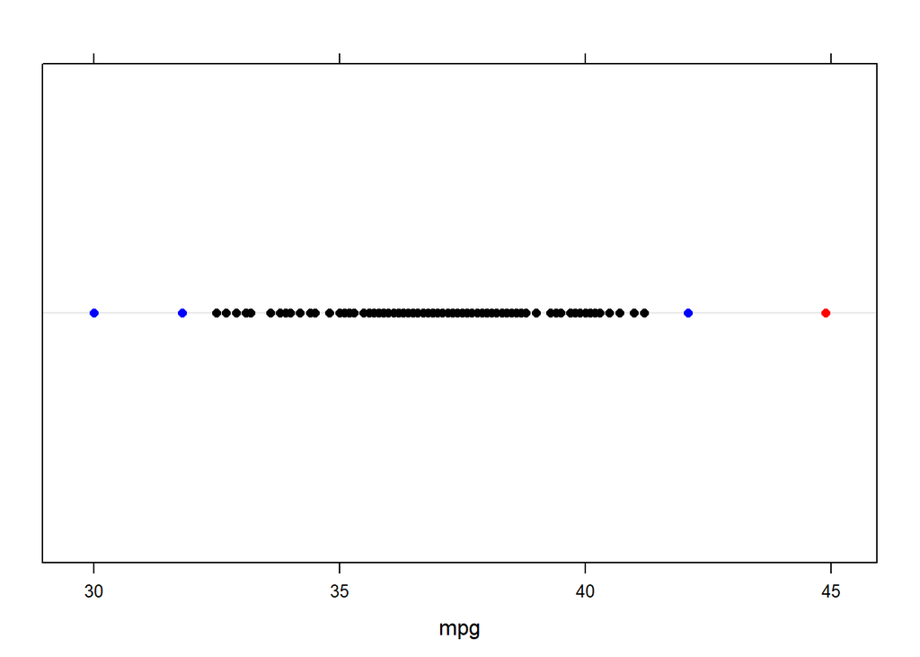

```r
mycol = ifelse(abs(mpg_zvalues)>3, "Red",
        ifelse(abs(mpg_zvalues)>=2 &abs(mpg_zvalues)<=3,"Blue", "Black"))

#Plot points with different plotting shapes
mypch = ifelse(abs(mpg_zvalues)>3, 20,
        ifelse(abs(mpg_zvalues)>=2 &abs(mpg_zvalues)<=3,21, 22))

#Use an installed library
# You will need to install the "lattice" package -- unless using the Lab computers
#In R go to Packages   -- select "install packages" choose a mirror and then the "lattice" package
# Now issue the following commands
library(lattice)
dotplot(mpg,col=mycol)
```

## Task 4

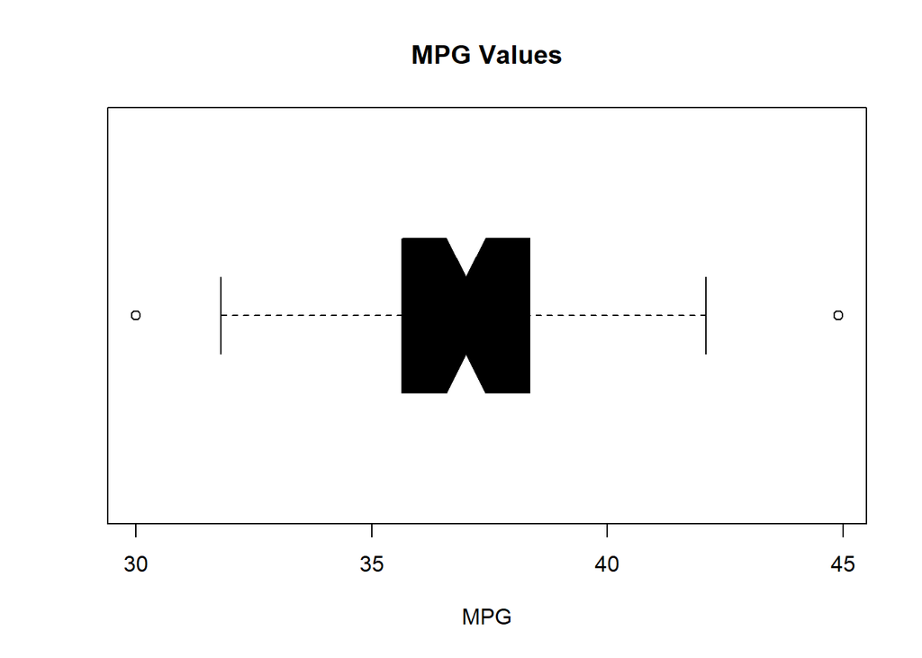

```r
boxplot(mpg, notch = TRUE, xlab = "MPG", col = "black", main = "MPG Values", horizontal = TRUE)
```

### Chebyshev’s theorem

This theorem states that for any quantitative distribution with standard deviation, $s =\sqrt{\frac{\sum_{i=1}^{n} (x_i - \bar{x})^2}{n-1}}$, that $\textit{at least} \hspace{4pt} (1-\frac{1}{k^2})$ of the distribution exists within $\pm ks, \hspace{2pt}k\in\mathbb{N},$ standard deviations of the arithmetic mean.

```r
stdev<-round(sd(mpg), digits = 2)

sd2=mpg[abs(mpg_zvalues)<=2]

mpg_mean=round(mean(mpg), digits = 2)
```

With Chebyshev’s theorem, we expect to observe that at least $(1- \frac{1}{2^2}) = .75 = 75\%$ of the fuel efficiency measurements fall within 2 standard deviations (4.84 mpg) of the arithmetic mean, 36.99.

Considering that 96 from a possible 100 measurements fall within two standard deviations of the mean, it is clear that Chebyshev wins!

### Emperical rule

```r
?hist
```

```
## starting httpd help server ... done
```